# Level of Physical Activity

# 1 Description of DataSchema variable

The description of harmonised variable is the following:

- Short name: `level_pa`
- Variable label: `Activity level`
- Variable description: `Level of physical activity/sedentary behaviours`
- Domain: `Lifestyle and health behaviours`
- Value type: `categorical`
- Category coding:

| **Code** | **Category Label** |
| --- | --- |
| 1 | a lot/high |
| 2 | fairly/moderate |
| 3 | not much/low |
| 4 | not at all/inactive |

- Category missings:

| **Code** | **Category Label** |
| --- | --- |
| 991 | CAPI/interviewer error |
| 992 | Impute |
| 993 | Disable to measure |
| 994 | Not attempt/not done |
| 995 | Does not answer |
| 996 | Not applicable |
| 997 | Refuse |
| 998 | Do not know |
| 999 | Missing |

# 2 Data process

## 2.1 England

### 2.1.1 Wave 1

Not found.

### 2.1.2 Wave 2

#### 2.1.2.1 Study-specific variable description

| **Name** | `palevel` |
| --- | --- |
| **Label** | `Physical activity summary` |
| **Table name** | `wave_2_derived_variables` |
| **Categories:** | `0 = Sedentary` `1 = Low` `2 = Moderate` `3 = High` |
| **Missings:** | `-1 = Not applicable` `-6 = See INWAVE` `-8 = Not known` |
| **Description** |  |

| Sample size | Missing values |
| --- | --- |
| 9432 | 139 |

Category

|  | 0 | 1 | 2 | 3 |
| --- | --- | --- | --- | --- |
| Frequency | 556.00 | 2309.00 | 4684.00 | 1744.00 |
| Percentage | 5.89 | 24.48 | 49.66 | 18.49 |

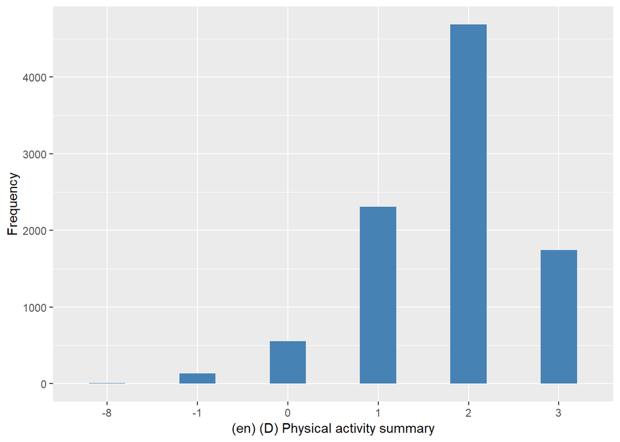

#### 2.1.2.2 Harmonisation algorithm

To compute `level_pa` from the study-specific variable it has to be recoded as follows:

- `0 into 4`
- `1 into 3`
- `3 into 1`
- `-8 into 998`
- `-6 into 996`
- `-1 into 996`

**R script:**

```r
ELSA_ds_w2 <- tibble(id = ELSA_w2$id)
ELSA_ds_w2$level_pa <- car::recode(ELSA_w2$palevel, "0 = 4;1 = 3;3 = 1;-8 = 998;-6 = 996;-1 = 996 ")
```

#### 2.1.2.3 Statistical description of the new harmonised variable

Activity level

| Sample size | Missing values |
| --- | --- |
| 9432 | 139 |

Category

|  | 1 | 2 | 3 | 4 |
| --- | --- | --- | --- | --- |
| Frequency | 1744.00 | 4684.00 | 2309.00 | 556.00 |
| Percentage | 18.49 | 49.66 | 24.48 | 5.89 |

Type of missing

|  | 991 | 992 | 993 | 994 | 995 | 996 | 997 | 998 | 999 | NA |
| --- | --- | --- | --- | --- | --- | --- | --- | --- | --- | --- |
| Frequency | 0 | 0 | 0 | 0 | 0 | 132.0 | 0 | 7.00 | 0 | 0 |
| Percentage | 0 | 0 | 0 | 0 | 0 | 1.4 | 0 | 0.07 | 0 | 0 |

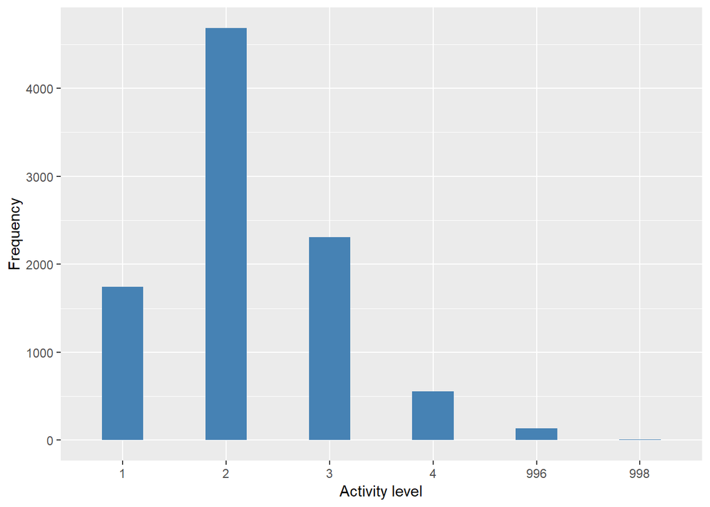

#### 2.1.2.4 Validation

### 2.1.3 Wave 3

#### 2.1.3.1 Study-specific variable description

| **Name** | `palevel` |
| --- | --- |
| **Label** | `Physical activity summary` |
| **Table name** | `wave_3_elsa_data_v4` |
| **Categories:** | `0 = Sedentary` `1 = Low` `2 = Moderate` `3 = High` |
| **Missings:** | `-8 = Not known` |
| **Description** |  |

palevel

| Sample size | Missing values |
| --- | --- |
| 9771 | 15 |

Category

|  | -8 | 0 | 1 | 2 | 3 |
| --- | --- | --- | --- | --- | --- |
| Frequency | 15.00 | 686.00 | 2263.00 | 4838.00 | 1969.00 |
| Percentage | 0.15 | 7.02 | 23.16 | 49.51 | 20.15 |

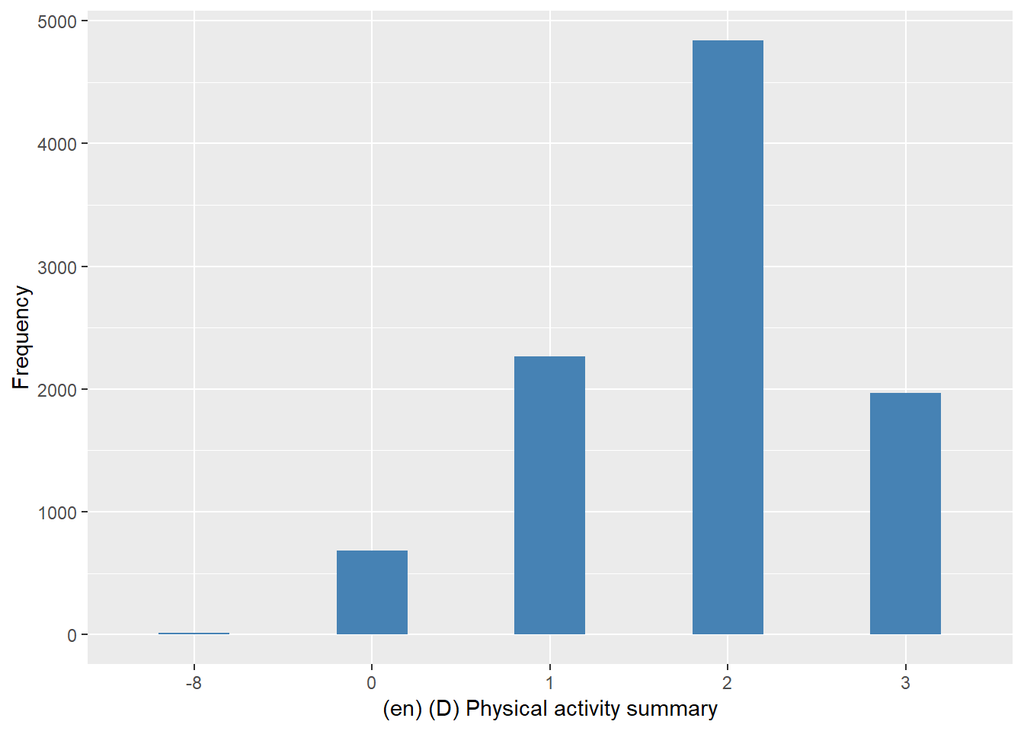

#### 2.1.3.2 Harmonisation algorithm

To compute `level_pa` from the study-specific variable it has to be recoded as follows:

- `0 into 4`
- `1 into 3`
- `3 into 1`
- `-8 into 998`

**R script:**

```r
ELSA_ds_w3 <- tibble(id = ELSA_w3$id)
ELSA_ds_w3$level_pa <- car::recode(ELSA_w3$palevel, "0 = 4;1 = 3;3 = 1;-8 = 998 ")
```

#### 2.1.3.3 Statistical description of the new harmonised variable

Activity level

| Sample size | Missing values |
| --- | --- |
| 9771 | 15 |

Category

|  | 1 | 2 | 3 | 4 |
| --- | --- | --- | --- | --- |
| Frequency | 1969.00 | 4838.00 | 2263.00 | 686.00 |
| Percentage | 20.15 | 49.51 | 23.16 | 7.02 |

Type of missing

|  | 991 | 992 | 993 | 994 | 995 | 996 | 997 | 998 | 999 | NA |
| --- | --- | --- | --- | --- | --- | --- | --- | --- | --- | --- |
| Frequency | 0 | 0 | 0 | 0 | 0 | 0 | 0 | 15.00 | 0 | 0 |
| Percentage | 0 | 0 | 0 | 0 | 0 | 0 | 0 | 0.15 | 0 | 0 |

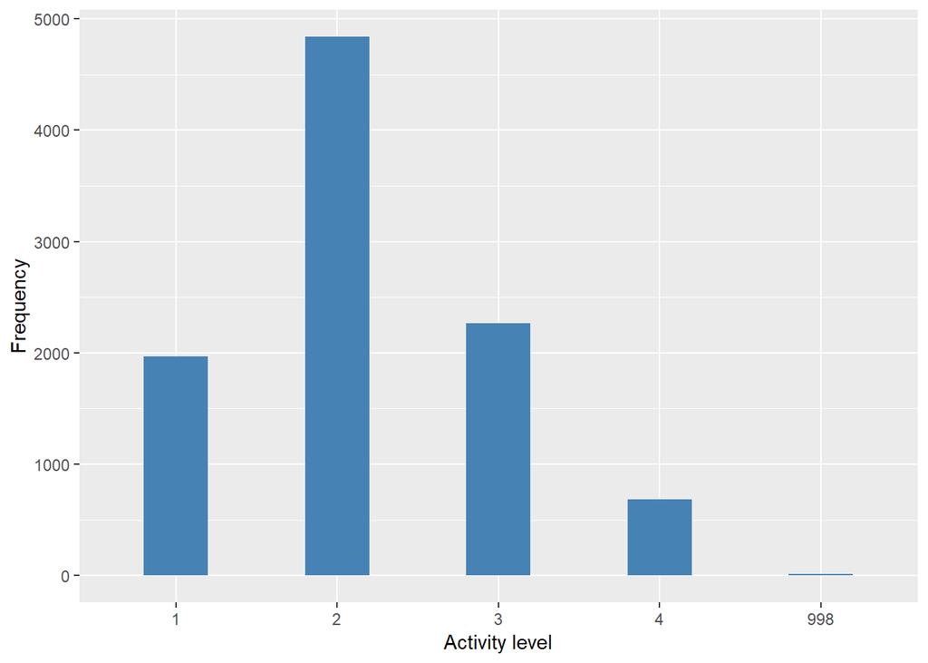

#### 2.1.3.4 Validation

### 2.1.4 Wave 4

#### 2.1.4.1 Study-specific variable description

| **Name** | `palevel` |
| --- | --- |
| **Label** | `Physical activity summary` |
| **Table name** | `wave_4_elsa_data_v3` |
| **Categories:** | `0 = Sedentary` `1 = Low` `2 = Moderate` `3 = High` |
| **Missings:** | `-8 = Not known` |
| **Description** |  |

palevel

| Sample size | Missing values |
| --- | --- |
| 11050 | 15 |

Category

|  | -8 | 0 | 1 | 2 | 3 |
| --- | --- | --- | --- | --- | --- |
| Frequency | 15.00 | 835.00 | 2562.00 | 5384.00 | 2254.0 |
| Percentage | 0.14 | 7.56 | 23.19 | 48.72 | 20.4 |

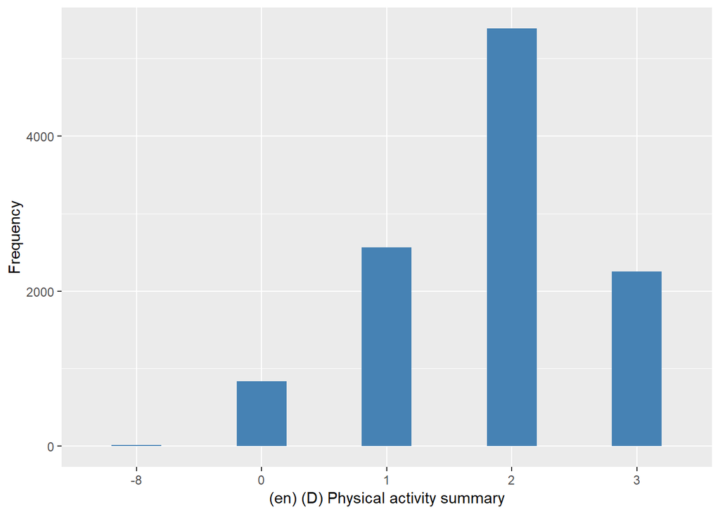

#### 2.1.4.2 Harmonisation algorithm

To compute `level_pa` from the study-specific variable it has to be recoded as follows:

- `0 into 4`
- `1 into 3`
- `3 into 1`
- `-8 into 998`

**R script:**

```r
ELSA_ds_w4 <- tibble(id = ELSA_w4$id)
ELSA_ds_w4$level_pa <- car::recode(ELSA_w4$palevel, "0 = 4;3 = 1;1 = 3;-8 = 998 ")
```

#### 2.1.4.3 Statistical description of the new harmonised variable

Activity level

| Sample size | Missing values |
| --- | --- |
| 11050 | 15 |

Category

|  | 1 | 2 | 3 | 4 |
| --- | --- | --- | --- | --- |
| Frequency | 2254.0 | 5384.00 | 2562.00 | 835.00 |
| Percentage | 20.4 | 48.72 | 23.19 | 7.56 |

Type of missing

|  | 991 | 992 | 993 | 994 | 995 | 996 | 997 | 998 | 999 | NA |
| --- | --- | --- | --- | --- | --- | --- | --- | --- | --- | --- |
| Frequency | 0 | 0 | 0 | 0 | 0 | 0 | 0 | 15.00 | 0 | 0 |
| Percentage | 0 | 0 | 0 | 0 | 0 | 0 | 0 | 0.14 | 0 | 0 |

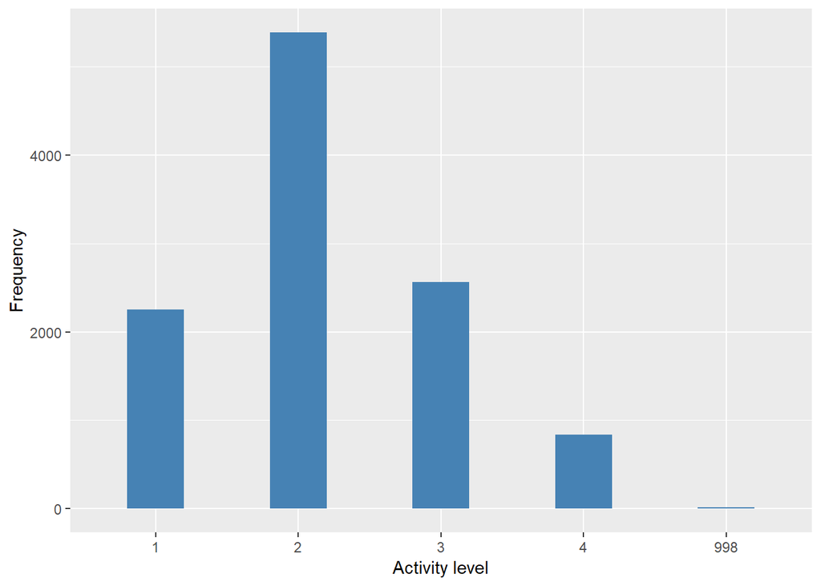

#### 2.1.4.4 Validation

### 2.1.5 Wave 5

#### 2.1.5.1 Study-specific variable description

| **Name** | `palevel` |
| --- | --- |
| **Label** | `Physical activity summary` |
| **Table name** | `wave_5_elsa_data_v4` |
| **Categories:** | `0 = Sedentary` `1 = Low` `2 = Moderate` `3 = High` |
| **Missings:** | `-8 = Not known` |
| **Description** |  |

palevel

| Sample size | Missing values |
| --- | --- |
| 10274 | 124 |

Category

|  | -8 | 0 | 1 | 2 | 3 |
| --- | --- | --- | --- | --- | --- |
| Frequency | 124.00 | 801.0 | 2432.00 | 4936.00 | 1981.00 |
| Percentage | 1.21 | 7.8 | 23.67 | 48.04 | 19.28 |

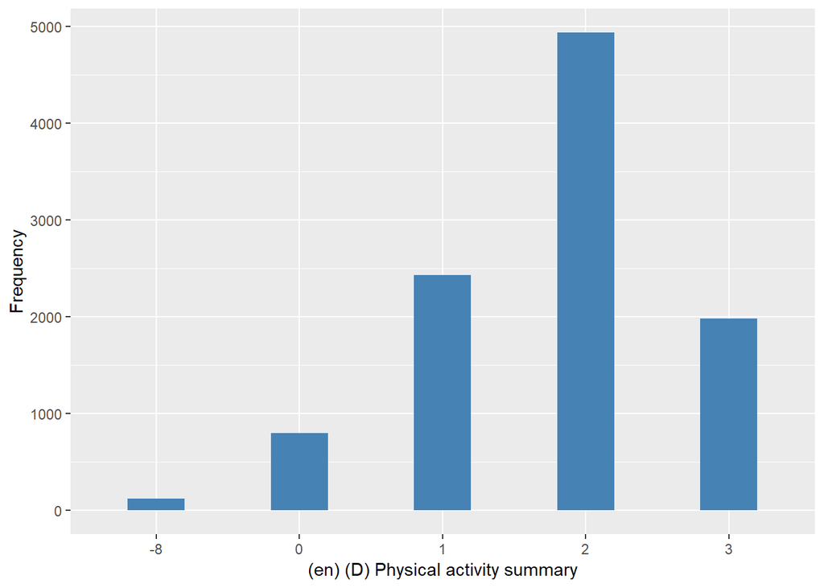

#### 2.1.5.2 Harmonisation algorithm

To compute `level_pa` from the study-specific variable it has to be recoded as follows:

- `0 into 4`
- `1 into 3`
- `2 into 2`
- `3 into 1`
- `-8 into 998`

**R script:**

```r
ELSA_ds_w5 <- tibble(id = ELSA_w5$id)
ELSA_ds_w5$level_pa <- car::recode(ELSA_w5$palevel, "0 = 4;3 = 1;1 = 3;-8 = 998 ")
```

#### 2.1.5.3 Statistical description of the new harmonised variable

Activity level

| Sample size | Missing values |
| --- | --- |
| 10274 | 124 |

Category

|  | 1 | 2 | 3 | 4 |
| --- | --- | --- | --- | --- |
| Frequency | 1981.00 | 4936.00 | 2432.00 | 801.0 |
| Percentage | 19.28 | 48.04 | 23.67 | 7.8 |

Type of missing

|  | 991 | 992 | 993 | 994 | 995 | 996 | 997 | 998 | 999 | NA |
| --- | --- | --- | --- | --- | --- | --- | --- | --- | --- | --- |
| Frequency | 0 | 0 | 0 | 0 | 0 | 0 | 0 | 124.00 | 0 | 0 |
| Percentage | 0 | 0 | 0 | 0 | 0 | 0 | 0 | 1.21 | 0 | 0 |

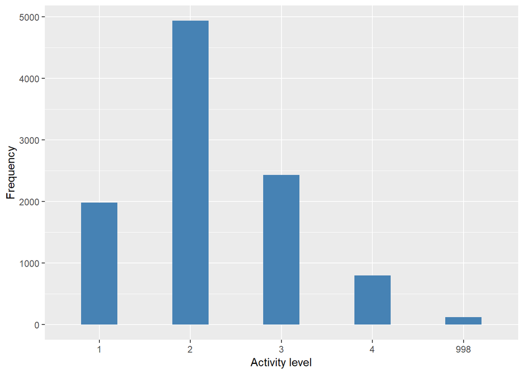

#### 2.1.5.4 Validation

### 2.1.6 Wave 6

Not found

### 2.1.7 Wave 7

Not found

## 2.2 Summary of descriptive statistics of the harmonised variable accross populations and waves

Two tables are generated:

1. Percentages of categories in each harmonised variable.
2. Frequencies and percentages of individuals with different trajectories. To avoid too large table, Only trajectories with percentages larger than 0.3 are shown.

Activity level

| val | label | W2 | W3 | W4 | W5 |
| --- | --- | --- | --- | --- | --- |
| 1 | a lot/high | 18.49 | 20.15 | 20.4 | 19.28 |
| 2 | fairly/moderate | 49.66 | 49.51 | 48.72 | 48.04 |
| 3 | not much/low | 24.48 | 23.16 | 23.19 | 23.67 |
| 4 | not at all/inactive | 5.89 | 7.02 | 7.56 | 7.8 |
| 991 | CAPI interviewer error | 0 | 0 | 0 | 0 |
| 992 | Impute | 0 | 0 | 0 | 0 |
| 993 | Disable to measure | 0 | 0 | 0 | 0 |
| 994 | Not attempt not done | 0 | 0 | 0 | 0 |
| 995 | Does not answer | 0 | 0 | 0 | 0 |
| 996 | Not applicable | 1.4 | 0 | 0 | 0 |
| 997 | Refuse | 0 | 0 | 0 | 0 |
| 998 | Do not know | 0.07 | 0.15 | 0.14 | 1.21 |
| 999 | Missing | 0 | 0 | 0 | 0 |
| NA | NA | 0 | 0 | 0 | 0 |
| n | sample size | 9432 | 9771 | 11050 | 10274 |

|  | val | frq | raw.prc |
| --- | --- | --- | --- |
| 1 | 1111 | 325 | 2.22 |
| 2 | 1112 | 115 | 0.78 |
| 6 | 1121 | 56 | 0.38 |
| 7 | 1122 | 101 | 0.69 |
| 23 | 11NANA | 63 | 0.43 |
| 24 | 1211 | 59 | 0.40 |
| 25 | 1212 | 60 | 0.41 |
| 29 | 1221 | 52 | 0.35 |
| 30 | 1222 | 195 | 1.33 |
| 46 | 12NANA | 46 | 0.31 |
| 89 | 1NANANA | 172 | 1.17 |
| 90 | 2111 | 87 | 0.59 |
| 91 | 2112 | 65 | 0.44 |
| 96 | 2122 | 130 | 0.89 |
| 112 | 21NANA | 46 | 0.31 |
| 113 | 2211 | 73 | 0.50 |
| 114 | 2212 | 132 | 0.90 |
| 117 | 2221 | 140 | 0.96 |
| 118 | 2222 | 981 | 6.69 |
| 119 | 2223 | 220 | 1.50 |
| 121 | 222NA | 149 | 1.02 |
| 123 | 2232 | 147 | 1.00 |
| 124 | 2233 | 141 | 0.96 |
| 126 | 223NA | 59 | 0.40 |
| 133 | 22NA2 | 57 | 0.39 |
| 136 | 22NANA | 258 | 1.76 |
| 142 | 2322 | 146 | 1.00 |
| 143 | 2323 | 81 | 0.55 |
| 147 | 2332 | 58 | 0.40 |
| 148 | 2333 | 110 | 0.75 |

[output cut: 55 more lines]

# 3 Quality estimation